# Z Transform: Averaging Lowpass And Combs

## Chris Tralie

```python
import numpy as np
import matplotlib.pyplot as plt
import IPython.display as ipd
```

We showed that the following difference equation is a lowpass filter of $x$

### $y[n] = x[n] + x[n-1]$

But let's go more general and look at more than one lag, or $A$ lags total

### $y[n] = x[n] + x[n-1] + x[n-2] + ... + x[n-A]$

Let's plug in our arbitrary "Z" phasor

### $y[n] = e^{i \omega n} + e^{i \omega (n-1)} + e^{i \omega (n-2)} + ... + e^{i \omega (n-A)}$

Factor out common terms

### $y[n] = e^{i \omega n}(1 + e^{-i \omega} + e^{-2i \omega} + ... + e^{-A i \omega} )$

Here's where we recognize that what we have is a [geometric series](https://mathworld.wolfram.com/GeometricSeries.html), and there's a closed form fraction that we can use in place of the sum

### $y[n] = e^{i \omega n}(\frac{1 - e^{-i(A+1)\omega)}}{1 - e^{-i \omega}} )$

We're making progress, but we want to get the point where we have an equation $Ae^{i \phi}$, where $A$ is a real number corresponding to the amplitude. To keep breaking this down, we're going to multiply by a fancy 1 like we did before

### $y[n] = e^{i \omega n}(\frac{1 - e^{-i(A+1)\omega)}}{1 - e^{-i \omega}} ) \frac{e^{i \omega/2}}{e^{i \omega/2}} $

Distributing this into the denominator, we get

### $y[n] = e^{i \omega n}(\frac{1 - e^{-i(A+1)\omega)}}{e^{i \omega/2} - e^{-i \omega/2}} ) \frac{e^{i \omega/2}}{1} $

At this point, we can use the fact that $e^{i x} - e^{-ix} = 2i \sin(x)$

### $y[n] = e^{i \omega n}(\frac{e^{i \omega/2} - e^{-i(A+1/2)\omega)}}{2 i \sin(\omega/2)} ) $

I don't like that $e^{i \omega/2}$ sitting in the numerator, so let me factor it out

### $y[n] = e^{i 3 \omega n /2 }(\frac{1 - e^{-i(A+1)\omega}}{2 i \sin(\omega/2)} ) $

Let's multiply by another fancy 1 which is

### $\frac{e^{i \omega (A+1)/2)}}{e^{i \omega (A+1)/2)}}$

and we get this

### $y[n] = \frac{e^{i 3 \omega n /2 }}{e^{i w (A+1)/2}} (\frac{e^{i w (A+1)/2} - e^{-i w (A+1)/2}}{2 i \sin(\omega/2)} ) $

Using our sine identity once more, we get the following

### $y[n] = \frac{e^{i 3 \omega n /2 }}{e^{i w (A+1)/2}} (\frac{2 i \sin(w (A+1)/2)}{2 i \sin(\omega/2)} ) $

which we can finally simplify into the $Ae^{i \phi}$ we were looking for!

### $y[n] = \frac{e^{i 3 \omega n /2 }}{e^{i w (A+1)/2}} (\frac{ \sin(w (A+1)/2)}{ \sin(\omega/2)} ) $

Let's focus on just the amplitude part so we can see how much different frequencies survive this filter

## $ |(\frac{ \sin(w (A+1)/2)}{ \sin(\omega/2)} ) |$

what we see is it gets tighter around the low frequencies the more lags we have. Actually, if we interpret this as an average of a bunch of samples in a window of extent $A$, then what this is saying is the more samples we average in a sliding window, the more high frequencies it tends to kill out

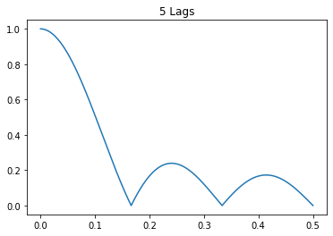

```python
f = np.linspace(0, 0.5, 1000)
w = 2*np.pi*f
A = 5
amp = np.abs(np.sin(w*(A+1)/2)/np.sin(w/2)/(A+1))
plt.plot(f, amp)
plt.title("{} Lags".format(A))
```

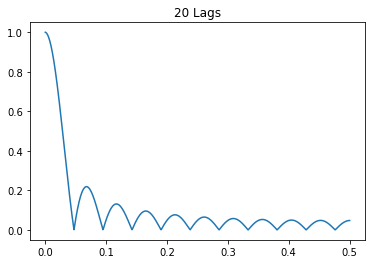

```python
A = 20
amp = np.abs(np.sin(w*(A+1)/2)/np.sin(w/2)/(A+1))
plt.plot(f, amp)
plt.title("{} Lags".format(A))
```

## Comb FIlters

For a comb filter, we can use almost the exact same analysis, except we have lags that occur by the comb width $T$ samples

### $y[n] = x[n] + x[n-T] + x[n-2T] + ... + x[n-AT]$

This leads to the following amplitude, where we simply multiply the argument to both sines by $T$

### $|y[n]| = |\frac{ \sin(w T(A+1)/2)}{ \sin(\omega T/2)} | $

What we see if we plot the amplitudes is that a set of harmonically related frequencies are promoted, as we saw before when we examined the result of comb filters before with the FFT (but now we can see it exactly over all frequencies). Furthermore, if we increase the number of lags, these frequencies stand out more. And if we increase the spacing, the frequencies get closer together; since the period is increasing, the frequency goes down

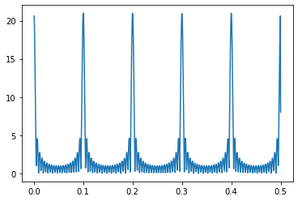

```python
f = np.linspace(0, 0.5, 1000)
w = 2*np.pi*f
A = 20
T = 10
amp = np.abs(np.sin(T*w*(A+1)/2)/np.sin(T*w/2))
plt.plot(f, amp)
```